# R:pems.utils Plotting

Karl Ropkins

2026-02-26

# Background

The **R** package **pems.utils** uses two main data types: **pems.element**s, data-series with assigned units, and **pems**, datasets of simultaneously logged **pems.element**s.

This document provides an overview of their plotting in **R**.

> For a quick and more general introduction to **pems.utils**, see [[>pems.utils introduction]](http://pems.r-forge.r-project.org/pems.utils.intro.html) or to return to the [[>website index]](http://pems.r-forge.r-project.org/index.html).

> If you have any suggestions how to make either **pems.utils** or this document better or you have any problems using either, please let me know [>email me].

> Unless you have setup **R** to automatically load **pems.utils**, you will need to load it e.g. using `library(pems.utils)` to use the functions described here.

**pems.utils** includes a number of specialist graphics functions developed specifically for use with **pems** and **pems.element** data types. However, **pems.utils** is primarily a data handling and analysis package, and outputs have been designed to allow users the flexibility to work with other graphics packages.

# Generic Plots:

The **pems.utils** package includes generic plotting methods for both **pems** and **pems.elements** data types.

So, both data types can be handled using standard **plot(…)** calls, e.g.:

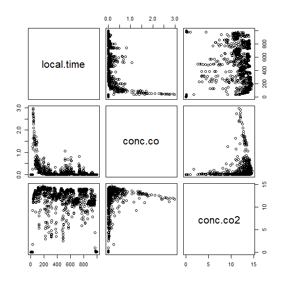

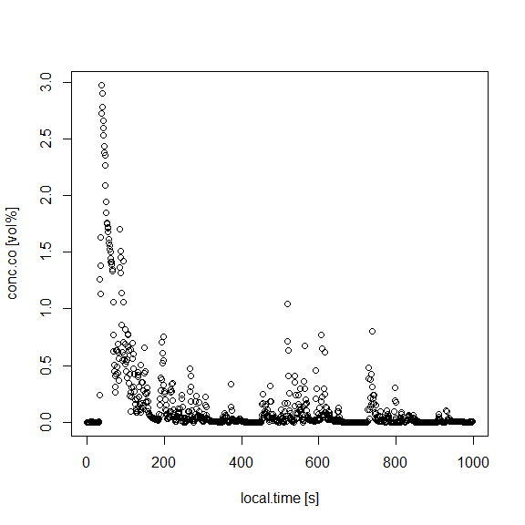

```r
plot(pems.1)
plot(pems.1$local.time, pems.1$conc.co)
```

> Here, **plot(pems, …)** behaves like a **plot(data.frame, …)** and generates a co-plot, and **plot(pems.element, …)** behaves like **plot(vector, …)** and generates a conventional scatterplot.

> These generic plots accept most common **plot** arguments, e.g. **type**, **col** and **lty**, making this is simple-to-use option for most **R** users.

> For more about other generic functions like **plot** in **pems.utils**, see [[>pems.utils generics]](http://pems.r-forge.r-project.org/pems.utils.generics.html).

# Working with other Graphics Packages

Although there are some important differences, discussed in the package introduction, **pems** behave in a similar fashion to other (row and column) data set objects like **data.frames** and **data.tables**, and **pems.elements** behave in a similar fashion to other **vector** objects like **numerics**, **characters** and **factors** when used with other packages.

So, generally, anything you can do in a graphic package with a **data.frame** or a **vector** you should be able to do with a **pems** or a **pems.element**, respectively.

For example, **pems** data sets can be treated like conventional **data.frames** in either **lattice** or **ggplot2** plots:

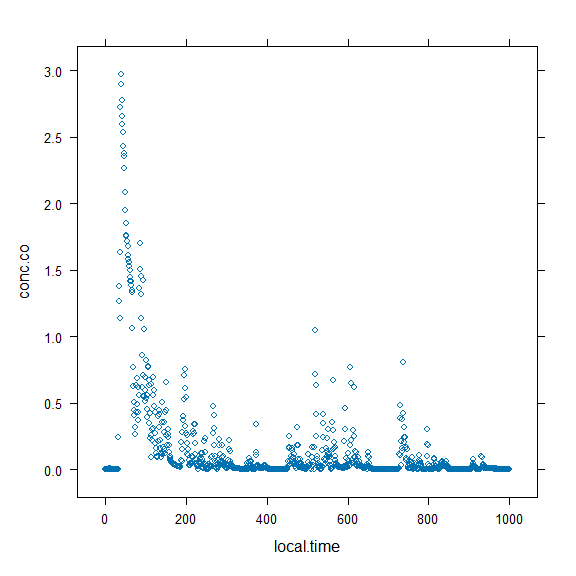

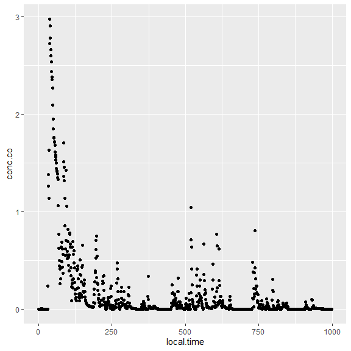

```r
require(lattice)
xyplot(conc.co~local.time, data=pems.1)
require(ggplot2)
ggplot(pems.1) + geom_point(aes(x=local.time, y=conc.co))
```

> If you are plotting **pems.utils** outputs with these or other packages and have any suggestions how to make either plot handling or this document better or you have any problems, please let me know. [>email me].

# **pemsPlot**

**pemsPlot** is the main workhorse function for plotting **pems.utils** outputs.

It accepts **x** and **y** arguments like **plot**, which can be supplied directly or sourced from a data set supplied as **data** in the same call.

Plot outputs can be easily modified using additional arguments and functions, e.g.:

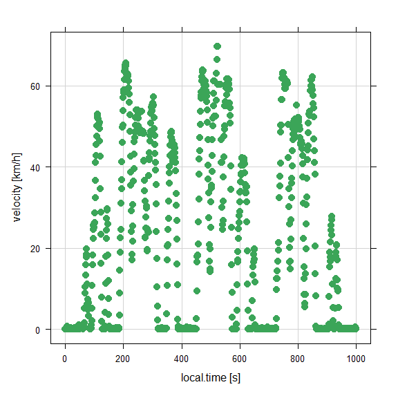

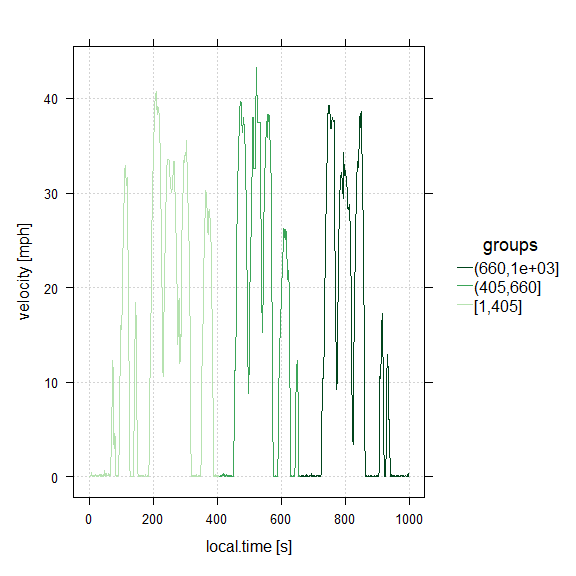

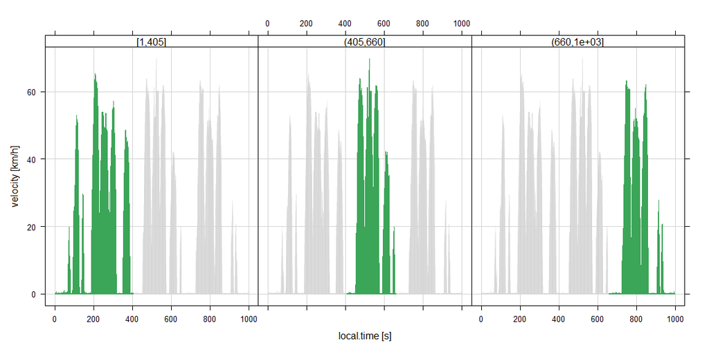

```r
#plot 1:default x/y plot
pemsPlot(local.time, velocity, data=pems.1)

#add a  'referencing' term for grouping, etc...
pems.1$ref <- refRow(pems.1, breaks=c(405,660))

#plot 2: grouped line plot with y axis reset to miles per hour
pemsPlot(local.time, velocity, data=pems.1, group=ref,
         type="l", grid.lty=3, y.to="mph")

#plot 3: conditioned type h plot with full dataset ghosts plotted
#(type h is a drop line plot;  h comes from histogram-like)
p <- pemsPlot(local.time, velocity, data=pems.1,
         cond=ref, type="h")
loa::add.XYZGhosts(p)
```

> **pemsPlots** accepts (optional) arguments: **z** which is by default linked to point size and color; **groups** for within-plot grouping and **cond** for multiple plot panelling.

> Like **plot**, it accepts common plotting arguments, e.g. **type** to change between point and line outputs, but it also accepts **loa** style commands, e.g. **grid.lty** to change the line style of grid lines without affecting other lines in the plots, and commands like **y.to** that access **pems** information to change plot element scales and units.

> Other functions can also be used to add addition elements to existing plots, e.g. here **add.XYZGhosts** from **loa** is used to add a ‘ghost’ versions of the full dataset to all panels in a multiple panel plot.

**pemsPlot** is highly flexible, and used with other **panel…** and **loa** **add…** functions, can be easily used to generate many plots commonly used in PEMS data analysis with just a few lines of code.

For example, data maps from plots of GPS latitude and longitude data:

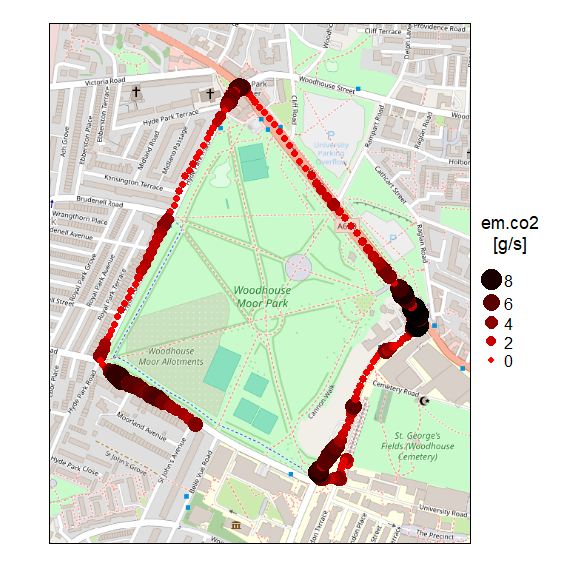

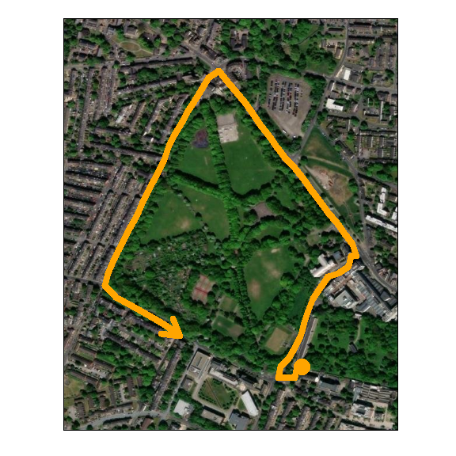

```r
#map 1: CO2 Emissions bubble plot, first 300 measurements
pems.1$em.co2 <- calcEm(conc.co2, data=pems.1)
p <- pemsPlot(longitude, latitude, em.co2,
              data=pems.1[1:300,], grid=FALSE,
              col.regions=c("red", "black"))
loa::add.LonLatMap(p, map.type="osm")

#map 2: vehicle journey path, first 300 measurements
p <- pemsPlot(longitude, latitude, col ="orange",
              data=pems.1[1:300,], grid=FALSE,
              panel=panel.routePath)
loa::add.LonLatMap(p, map.type="esri-imagery")
```

> Both examples limit the plot range to the first 300 rows of the **pems.1** dataset.

> In map 1 the supplied emission measurement, **em.co2**, is used as the **z** **pemsPlot** argument to generate a bubble plot. Other plot arguments are also used to modify the plot appearance, e.g. **col.regions** to change the palette coloring points, and then **add.LonLatMap** from **loa** is used to add a same-location map, in this case an open street map tile.

> The map layers were generated using code in **loaMapPlot** in **loa**, and the map layers are (c) OpenStreetMap contributors.

Plots can be easily extended to include multiple time-series and axes, e.g.:

[figure not shown]

```r
#calculate emissions for pems.1 CO, NOx and HCs:
pems.1$em.co <- calcEm(conc.co, data=pems.1)
pems.1$em.nox <- calcEm(conc.nox, data=pems.1)
pems.1$em.hc <- calcEm(conc.hc, data=pems.1)

#multi-species time-series of exhaust emissions
#superimposed on the emitting vehicle's speed profile
p <- pemsPlot(local.time, cpe(em.co, em.nox*5, em.hc*10),
         data=pems.1, type="l", ylab="",
         col=c("red", "blue", "darkgreen"),
         key.groups.main="Emissions\n[g/sec]",
         key.position="left")
p <- loa::add.Y2Axis(p, ylab="speed", col="grey", rescale=200)
loa::add.XYPolygon(p, x=local.time, y=velocity,
              data=pems.1, col="grey",
              y2.scale=TRUE, first=TRUE)
```

> Here, the **cpe** function is used to group multiple **y** axis data-series and scale them manually, and other arguments are used to control plot appearance and layout, e.g. **col** to color y time-series directly and *key…* arguments are used to position and label the key.

> Then **add…** functions are used to add a second y-axis, and a polygon layer, plotted on that second axis scale, showing the vehicle speed profile.

# Other Packaged Plots

Other plots included in the **pems.utils** package are meant for use with specific pems.elements.

## WatsonPlot

Supplied speed and acceleration time-series, the **WatsonPlot** generates variations on Watson’s classic speed/accel frequency distribution plot[^1], e.g.:

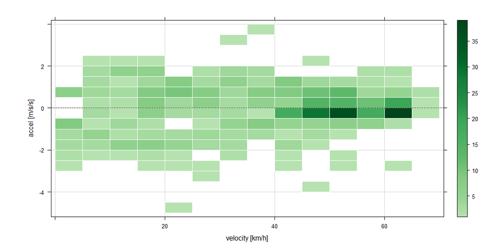

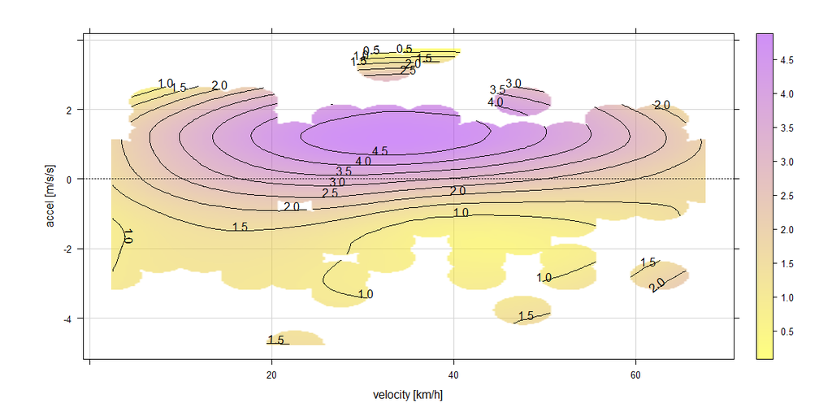

```r
#calculate acceleration and CO2 emissions
pems.1$accel <- calcAccel(velocity, local.time,
                          data = pems.1)
pems.1$em.co2 <- calcEm(conc.co2, data = pems.1)

#plot 1: speed/accel frequency distribution as bin plot
WatsonPlot(velocity, accel, data=pems.1, omit.stopped="cells")

#plot 2: speed/accel/emissions distribution as fitted surface
WatsonPlot(velocity, accel, em.co2, data=pems.1, plot.type=4,
           omit.stopped="points", too.far=0.05,
           col.regions=c("yellow", "purple"))
```

> The **WatsonPlot** generates frequency distributions when supplied *x* and *y* time-series, and z-statistic distributions when supplied **x**, **y** and **z** time-series.

> Idling and/or stopped vehicle data can often dominate PEMS activity data, so the function includes an extra argument, **omit.stopped**, which provides options for handling related data. Options are **points**, which removes stopped-vehicle data before binning the data, and **cells**, which removes any cells containing stopped-vehicle data after binning it.

> The **WatsonPlot** includes several plot types. The examples shown here are a bin plot, which is the default plot output, and **plot.type = 4**, which is a fitted surface (used in second plot above). By default, surface fits are extrapolated across the full data range, but the extra argument **too.far** can be used to limit the amount of extrapolation.)

## The **coldStartPlot**:

Supplied local time and emissions time-series, the **coldStartPlot** generates cold start emissions plots, e.g.:

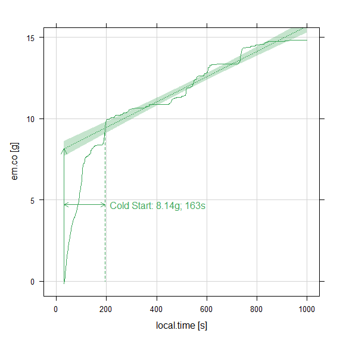

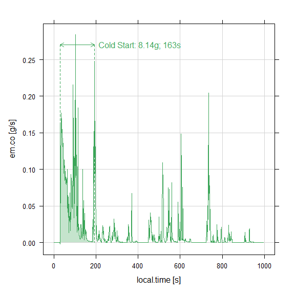

```r
#calculate CO emissions
pems.1$em.co <- calcEm(conc.co, data = pems.1)

#plot 1: cold start accumulative emissions
coldStartPlot(local.time, em.co, data=pems.1, engine.on=30)

#plot 2: cold start emission profile
coldStartPlot(local.time, em.co, data=pems.1, engine.on=30,
              plot.type=2)
```

> By default the **coldStartPlot** generates a conventional accumulated emissions profile[^2], fits a cold start model to that data, and reports the estimated cold start contribution and cold start operating time.

> Because PEMS systems are often started before the monitored vehicle engine, the extra argument **engine.on** can be used to exclude an pre-engine-on data from model inputs and calculations.

> The cold start end point is automatically assigned using a related **pems.utils** function **fitColdStart**[^3]. The function currently includes two variations on the automatic cold start assignment model: a single break-point fit to the accumulated emissions profile (model 1) and a modification of that (model 2). Model 2 is the current default.

> The default accumulated emisssion profile **coldStartPlot** is widely used when reporting cold start emissions. One other option, an emission profile cold start contribution plot, is also included as **plot.type** 2.

## VSPPlot and VSPBinPlot

Supplied vehicle specific power (VSP) and emissions time-series, the **VSPPlot** generates a VSP/emission plot, and supplied binned VSP data, the **VSPBinPlot** generates binned VSP profiles, e.g.:

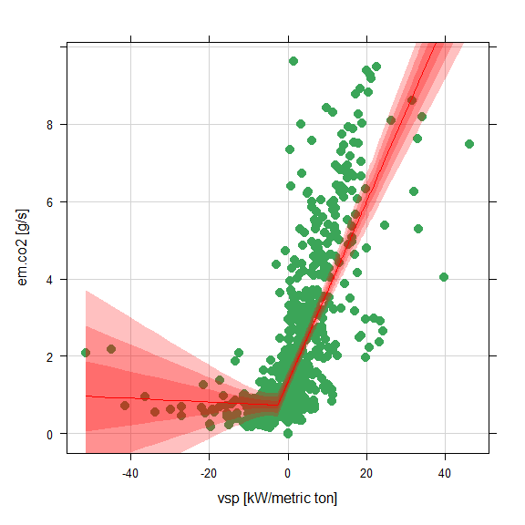

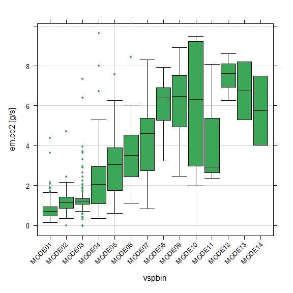

```r
#calculate VSP, VSPBins and CO2 emissions
pems.1 <- pems.utils::pems.1
pems.1$vsp <- calcVSP(velocity, time = local.time, data = pems.1)
pems.1$vspbin <- refVSPBin(vsp, data=pems.1)
pems.1$em.co2 <- calcEm(conc.co2, data = pems.1)

#align CO2 emissions with VSP
pems.1 <- cAlign(vsp~em.co2, pems.1, output="pems")

#plot 1: VSPPlot of CO2 emissions with break-point model fitted
VSPPlot(vsp, em.co2, data = pems.1, break.point = TRUE,
        break.point.col="red")

#plot 2: VSPBinPlot of CO2 emissions as boxplot
VSPBinPlot(vspbin, em.co2, data=pems.1, plot.type=2)
```

> By default, **VSPPlot** generates a scatter plot of the supplied VSP and emissions data, but LOESS curves or break-point lines can also be added using the extra arguments **loess** and **break.point**, and modified by extension as in earlier examples.

> **VSPBinPlot** generates a range of summary statistics plots for binned VSP data. By default, it generates a bar plot of VSP bin counts if suppied just the binned VSP data or a bar plot of binned VSP data mean emissions measurements if supplied binned VSP and emissions time-series. The statistical calculated if two inputs are supplied can also been modified using the additional argument **stat**.

These specialist plots made use **pems** and **pems.element** properties, e.g.:

> **pems** units handling, see [[>pems.utils units]](http://pems.r-forge.r-project.org/pems.utils.units.html)

> **pems** generics, see [[>pems.utils generics]](http://pems.r-forge.r-project.org/pems.utils.generics.html)

> If you have any suggestions how to make either **pems.utils** or this document better or you have any problems using either, please let me know. [>email me].

> Return to the [[>website index]](http://pems.r-forge.r-project.org/index.html) or [[>introduction]](http://pems.r-forge.r-project.org/pems.utils.intro.html).
[^1]: Watson, H.C., 1995. Effects of a wide range of drive cycles on the emissions from vehicles of three levels of technology. SAE transactions, pp.190-203.
[^2]: Heeb, N., Forss, A.-M., Wilhelm, P. Comparison of methane, benzene and alkyl benzenes cold start emission data of EURO I and EURO II three-way catalyst passenger cars and light duty vehicles from time resolved exhaust gas analysis. Proceedings of the International Symposium on Transport and Air Pollution, Boulder Colorado USA, September 17-19, 2001.
[^3]: Based on methods described Ropkins, K, Li, H and Carslaw, DC Real-World Cold Start Emissions from Vehicles in the UK On-Road Vehicle Fleet. In: 20th CRC On-Road Vehicle Emission Workshop, 22 - 24 March 2010, San Diego, US